# PackageTutorial

Zhiwen Tan

## Introduction

`BCClong` is an R package for performing Bayesian Consensus Clustering (BCC) model for clustering continuous, discrete and categorical longitudinal data, which are commonly seen in many clinical studies. This document gives a tour of BCClong package.

see `help(package = "BCClong")` for more information and references provided by `citation("BCClong")`

To download **BCClong**, use the following commands:

```r
require("devtools")
devtools::install_github("ZhiwenT/BCClong", build_vignettes = TRUE)
library("BCClong")
```

To list all functions available in this package:

```r
ls("package:BCClong")
```

## Components

Currently, there are 1 function *BCC.multi* in this package which will provide a summary statistics for the computed model. To use this function, the input dataset requires some pre-process. Here, we are given an example to provide an work flow for this package.

## Pre-process (Setting up)

In this example, the PBCseq data was used as it is an public data set. We are only interested in the data before 910 days (2.5 years).

```r
library(mixAK)
```

```r
library(ggplot2)
library(cowplot)
data(PBCseq);head(PBCseq)
```

```
#>   id sex   fsex drug           fdrug      age fu.days alive status  fstatus
#> 1  1   1 female    1 D-penicillamine 58.76523     400   399      2    death
#> 2  1   1 female    1 D-penicillamine 58.76523     400   399      2    death
#> 3  2   1 female    1 D-penicillamine 56.44627    5169  5169      0 censored
#> 4  2   1 female    1 D-penicillamine 56.44627    5169  5169      0 censored
#> 5  2   1 female    1 D-penicillamine 56.44627    5169  5169      0 censored
#> 6  2   1 female    1 D-penicillamine 56.44627    5169  5169      0 censored
#>   delta.death delta.ltx.death day     month ascites fascites hepatom fhepatom
#> 1           1               1   0  0.000000       1      yes       1      yes
#> 2           1               1 192  6.308008       1      yes       1      yes
#> 3           0               0   0  0.000000       0       no       1      yes
#> 4           0               0 182  5.979466       0       no       1      yes
#> 5           0               0 365 11.991786       0       no       1      yes
#> 6           0               0 768 25.232033       0       no       1      yes
#>   spiders fspiders edema fedema stage fstage bili       lbili albumin  lalbumin
```

[output cut: 20 more lines]

```r
# patients known to be alive  and without liver transplantation at 910 days of follow-up
idx <- unique(PBCseq[PBCseq$alive>910,]$id); length(idx)
```

```
#> [1] 260
```

```r
dnew910 <- PBCseq[PBCseq$id %in% idx,]; length(unique(dnew910$id))
```

```
#> [1] 260
```

```r
dnew910$time <-  dnew910$month
dnew910$time <-  dnew910$month - mean(dnew910$month,na.rm=TRUE)
dnew910$time2 <-  dnew910$time^2

# use only data before 910 days (2.5 years)
dnew910.before <- dnew910[dnew910$day<=910,]; length(unique(dnew910.before$id))
```

```
#> [1] 260
```

```r
# create a new ID variable with values from 1 to N;
subj <- unique(dnew910.before$id)
N <- length(subj)
id.new <- NULL
for (i in 1:N) {id.new   <- c(id.new,
                              rep(i,length(dnew910.before[dnew910.before$id==subj[i],]$id)))}
dnew910.before$id.new <- id.new
```

## Fit BCC Model Using BCC.multi Function

```r
set.seed(2002)
fit.BCC <- BCClong::BCC.multi (
  mydat = list(dnew910.before$lbili,dnew910.before$lsgot,dnew910.before$spiders),
  dist = c("gaussian","gaussian","binomial"),
  id = list(dnew910.before$id.new,dnew910.before$id.new,dnew910.before$id.new),
  time = list(dnew910.before$time,dnew910.before$time,dnew910.before$time),
  formula =list(y ~ time +  (1|id),
                y ~ time +  (1|id),
                y ~ time +  (1|id)),
  num.cluster = 2,
  hyper.par  = list(delta=1,a.star=1,b.star=1,aa0=0.001, bb0=0.001, ww0=0,vv0=25, cc0=0.001, dd0=0.001,rr0=4,RR0=3),
  sigma.sq.e.common = 1,
  c.ga.tuning = list(1,1,1),            # tuning parameter for MH algorithm (fixed effect parameters), each parameter corresponds to an outcome/marker
  c.theta.tuning = list(1,1,1),     # tuning parameter for MH algorithm (random effect), each parameter corresponds to an outcome/marker
  adaptive.tuning = 0,              # adaptive tuning parameters, 1 - yes, 0 - no
  align.clusters=0,         # assign clusters
  alpha.common=0,               # 1 - common alpha, 0 - separate alphas for each outcome
  sig.var = 0,              # 1 - unstructured random effect variance, 0 - diagonal random effect variance structure
  initials= NULL,           # initial values for model parameters
  initial.cluster.membership = "mixAK", # "mixAK" or "random"
  print.info="FALSE",
  burn.in = 2000,           # number of samples discarded
  thin = 10,                # thinning
  per = 100,                # output information every "per" iteration
  max.iter = 12000)             # maximum number of iteration
```

```r
# pre-compiled result
fit.BCC <- readRDS("../inst/extdata/BCC.rds")
```

To print the summary statistics for all parameters

```r
fit.BCC$summary.stat
```

[output not shown]

To print the proportion for each cluster (mean, sd, 2.5% and 97.5% percentile) geweke statistics (geweke.stat) between -2 and 2 suggests the parameters converge

```r
fit.BCC$summary.stat$PPI
```

[output not shown]

To make a trace plot for PPI to inspect convergence

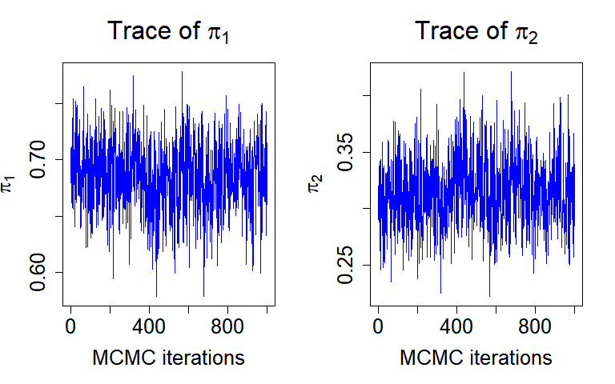

```r
num.sample <- (fit.BCC$max.iter -  fit.BCC$burn.in)/fit.BCC$thin # number of MCMC sample
par(mfrow=c(1,2))
plot(1:num.sample,fit.BCC$PPI[,1],type="l",col="blue" ,
     xlab="MCMC iterations",ylab=expression(pi[1]),main= expression(paste("Trace of ",pi[1],sep="")),
     cex.lab=1.6,cex.axis=1.6,cex.main=2)
plot(1:num.sample,fit.BCC$PPI[,2],type="l",col="blue" ,
     xlab="MCMC iterations",ylab=expression(pi[2]),main= expression(paste("Trace of ",pi[2],sep="")),
     cex.lab=1.6,cex.axis=1.6,cex.main=2)
```

Same thing can be done for the adherence parameters alpha for each marker

```r
fit.BCC$summary.stat$ALPHA
```

```
#>                   [,1]        [,2]         [,3]
#> mean        0.98439849  0.79265517  0.505191510
#> sd          0.01548626  0.03305572  0.005164409
#> 2.5%        0.94560041  0.72895316  0.500107366
#> 97.5%       0.99943590  0.85725053  0.518940324
#> geweke.stat 0.05668366 -0.92889526 -1.072545559
```

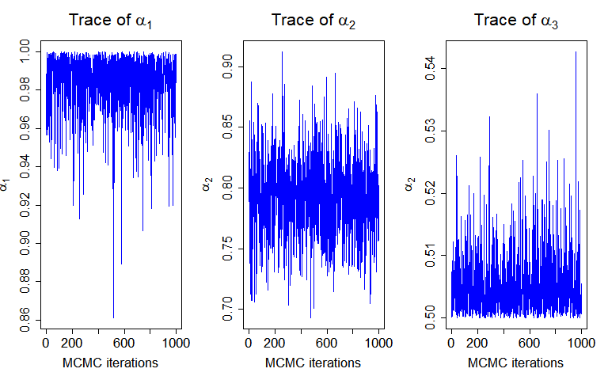

```r
# making a trace plot for alpha to inspect convergence
par(mfrow=c(1,3))
plot(1:num.sample,fit.BCC$ALPHA[,1],type="l",col="blue" ,
     xlab="MCMC iterations",ylab=expression(alpha[1]),main= expression(paste("Trace of ",alpha[1],sep="")),
     cex.lab=1.6,cex.axis=1.6,cex.main=2)
plot(1:num.sample,fit.BCC$ALPHA[,2],type="l",col="blue" ,
     xlab="MCMC iterations",ylab=expression(alpha[2]),main= expression(paste("Trace of ",alpha[2],sep="")),
     cex.lab=1.6,cex.axis=1.6,cex.main=2)
plot(1:num.sample,fit.BCC$ALPHA[,3],type="l",col="blue" ,
     xlab="MCMC iterations",ylab=expression(alpha[2]),main= expression(paste("Trace of ",alpha[3],sep="")),
     cex.lab=1.6,cex.axis=1.6,cex.main=2)
```